# MATH 216: Assignment 3

Nick Bermingham

# Instructions

- submit the .html file to Canvas
- you are encouraged to work together and ask your peers questions. Each person should submit their own work.
- You may share parts of your code to ask or answer questions on Slack. You should avoid sharing (copying and pasting) the entirety of your answers.
- make sure you include at least one acknowledgement

### Loading the data

The dataset `nycflights13` contains information on all flights that departed NYC (i.e. JFK, LGA or EWR) in 2013. Load it the data using the code below.

```r
#To load directly from `nycflights13` package
# make sure you have ran install.packages("nycflights13")
library(nycflights13)
#tblflights <- tbl_df(flights)

#OR
# to load from local .csv file
tblflights <- read.csv("tblflights.csv")
```

Take a look at the data. Note what the column names are. Note what each row represents.

### Data Description

- **year, month, day** Date of departure
- **dep_time, arr_time** Actual departure and arrival times (format HHMM or HMM), local tz.
- **sched_dep_time, sched_arr_time** Scheduled departure and arrival times (format HHMM or HMM), local tz.
- **dep_delay, arr_delay** Departure and arrival delays, in minutes. Negative times represent early departures/arrivals.
- **carrier** Two letter carrier abbreviation. See table below to get full names of carriers
- **flight** Flight number.
- **tailnum** Plane tail number
- **origin, dest** Origin and destination.
- **air_time** Amount of time spent in the air, in minutes.
- **distance** Distance between airports, in miles.
- **hour, minute** Time of scheduled departure broken into hour and minutes.}

```r
#the airline codes can be found using the following code
tbl_df(airlines)
```

```
## # A tibble: 16 x 2
##    carrier name
##    <chr>   <chr>
##  1 9E      Endeavor Air Inc.
##  2 AA      American Airlines Inc.
##  3 AS      Alaska Airlines Inc.
##  4 B6      JetBlue Airways
##  5 DL      Delta Air Lines Inc.
##  6 EV      ExpressJet Airlines Inc.
##  7 F9      Frontier Airlines Inc.
##  8 FL      AirTran Airways Corporation
##  9 HA      Hawaiian Airlines Inc.
## 10 MQ      Envoy Air
## 11 OO      SkyWest Airlines Inc.
## 12 UA      United Air Lines Inc.
## 13 US      US Airways Inc.
## 14 VX      Virgin America
## 15 WN      Southwest Airlines Co.
## 16 YV      Mesa Airlines Inc.
```

# Problems

## Question 1

Create a new column called `route` which contains the both the origin and destination airport codes seperated by a dash. For example, a flight that goes from JFK to MIA should display `JFK-MIA` in this new column.

```r
mutate(.data = tblflights, route = paste(origin, dest, sep = "-"))
```

## Question 2

How many different airlines are there?

```r
length(table(tblflights$carrier))
```

```
## [1] 16
```

There are 16 different airlines

Determine the mean departure delay for each of these different airlines. Note: the var `dep_delay` is the departure delay in minutes.

```r
tblflights %>%
  filter(is.na(dep_delay) == 0) %>%
  group_by(carrier) %>%
  summarize(mean.delay = mean(dep_delay))
```

```
## # A tibble: 16 x 2
##    carrier mean.delay
##    <fct>        <dbl>
##  1 9E           16.7
##  2 AA            8.59
##  3 AS            5.80
##  4 B6           13.0
##  5 DL            9.26
##  6 EV           20.0
##  7 F9           20.2
##  8 FL           18.7
##  9 HA            4.90
## 10 MQ           10.6
## 11 OO           12.6
## 12 UA           12.1
## 13 US            3.78
## 14 VX           12.9
## 15 WN           17.7
## 16 YV           19.0
```

## Question 4

Print a list of the 10 flights with the longest departure delays. Your list should include the date, schedule departure time, actual departure time, carrier, the departure airport and destination airport.

```r
tblflights %>%
  arrange(-dep_delay) %>%
  select(year, month, day, sched_dep_time, dep_time, carrier, origin, dest, dep_delay) %>%
  head(n = 10)
```

```
##    year month day sched_dep_time dep_time carrier origin dest dep_delay
## 1  2013     1   9            900      641      HA    JFK  HNL      1301
## 2  2013     6  15           1935     1432      MQ    JFK  CMH      1137
## 3  2013     1  10           1635     1121      MQ    EWR  ORD      1126
## 4  2013     9  20           1845     1139      AA    JFK  SFO      1014
## 5  2013     7  22           1600      845      MQ    JFK  CVG      1005
## 6  2013     4  10           1900     1100      DL    JFK  TPA       960
## 7  2013     3  17            810     2321      DL    LGA  MSP       911
## 8  2013     6  27           1900      959      DL    JFK  PDX       899
## 9  2013     7  22            759     2257      DL    LGA  ATL       898
## 10 2013    12   5           1700      756      AA    EWR  MIA       896
```

Optional: include a meme of how you would feel if you were on one of these 10 flights

## Question 5

Create two histograms - one for the departure delays and one for the arrival delays. Make sure they are well-labeled (have a title, x and y axis labels, etc.)

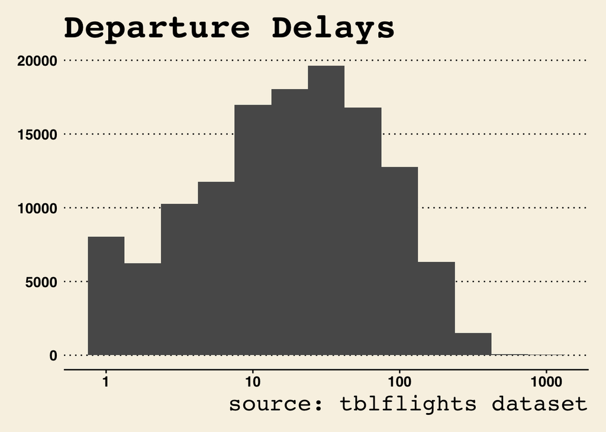

```r
tblflights %>%
  filter(is.na(dep_delay) == 0 & dep_delay >= 0) %>%
  ggplot(aes(dep_delay)) +
  theme_wsj() +
  geom_histogram(binwidth = 0.25, na.rm = TRUE) +
  labs(title = "Departure Delays",
         x = "Departure Delay (in minutes)",
         y = "Frequency",
         caption = "source: tblflights dataset") +
  scale_x_log10()
```

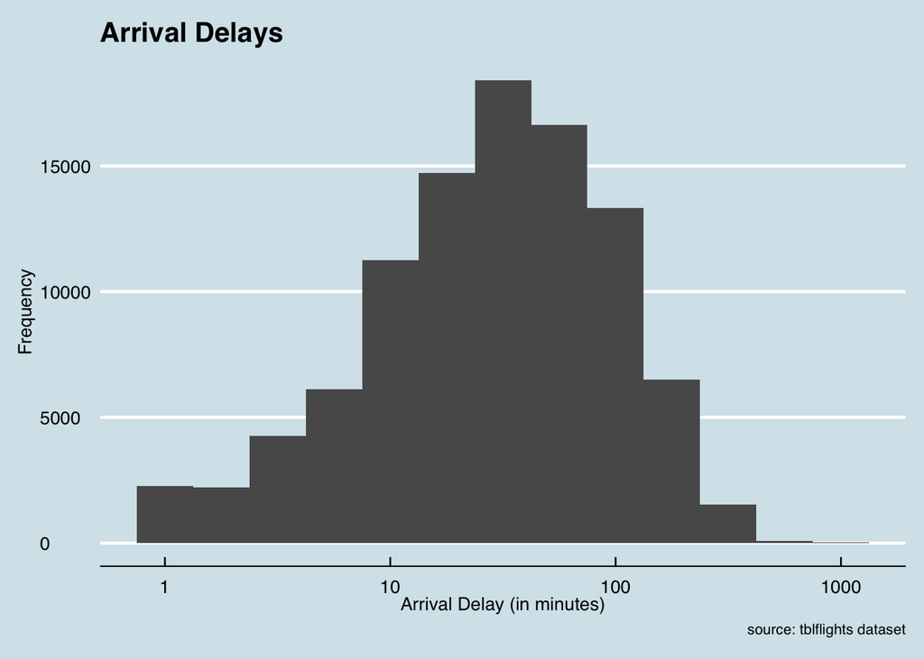

```r
tblflights %>%
  filter(is.na(dep_delay) == 0 & dep_delay >= 0) %>%
  ggplot(aes(arr_delay)) +
  geom_histogram(binwidth = 0.25, na.rm = TRUE) +
  theme_economist() +
  labs(title = "Arrival Delays",
         x = "Arrival Delay (in minutes)",
         y = "Frequency",
         caption = "source: tblflights dataset") +
  scale_x_log10()
```

## Question 6

For all the flights JFK - LAX, create a side-by-side boxplot to compare the arrival delay across all carriers. Make sure your plot is well-labelled (have a title, x and y axis labels, etc.)

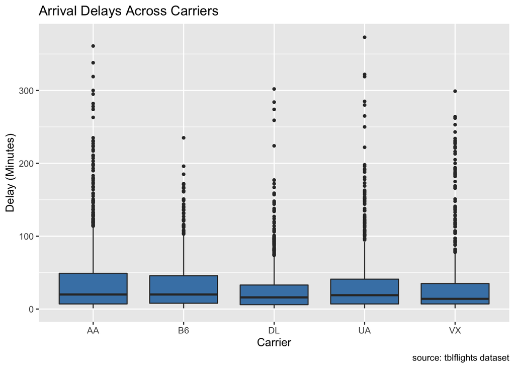

```r
tblflights %>%
  filter(origin == "JFK", dest == "LAX", arr_delay > 0, arr_delay <= 400) %>%
  ggplot(aes(x = carrier, y = arr_delay)) +
  geom_boxplot(fill = "steelblue", outlier.size = 1) +
  labs(title = "Arrival Delays Across Carriers",
         x = "Carrier",
         y = "Delay (Minutes)",
         caption = "source: tblflights dataset")
```

## Question 7

Create a table called `carrier_flights_over_time` that displays the count of the number of flights for all carriers across all months in wide format.

Hint: the first column should be all the carriers, the first row should be all the months. The data inside the table should be the number of flights.

```r
carrier_flights_over_time <- tblflights %>%
  group_by(carrier, month) %>%
  summarize(sum = length(carrier)) %>%
  spread(key = month, value = sum)

carrier_flights_over_time
```

```
## # A tibble: 16 x 13
## # Groups:   carrier [16]
##    carrier   `1`   `2`   `3`   `4`   `5`   `6`   `7`   `8`   `9`  `10`  `11`
##    <fct>   <int> <int> <int> <int> <int> <int> <int> <int> <int> <int> <int>
##  1 9E       1573  1459  1627  1511  1462  1437  1494  1456  1540  1673  1595
##  2 AA       2794  2517  2787  2722  2803  2757  2882  2856  2614  2715  2577
##  3 AS         62    56    62    60    62    60    62    62    60    62    52
##  4 B6       4427  4103  4772  4517  4576  4622  4984  4952  4291  4361  4289
##  5 DL       3690  3444  4189  4092  4082  4126  4251  4318  3883  4093  3849
##  6 EV       4171  3827  4726  4561  4817  4456  4641  4563  4725  4908  4471
##  7 F9         59    49    57    57    58    55    58    55    58    57    61
##  8 FL        328   296   316   311   325   252   263   263   255   236   202
##  9 HA         31    28    31    30    31    30    31    31    25    21    25
## 10 MQ       2271  2044  2256  2211  2284  2178  2261  2263  2206  2228  2056
## 11 OO          1    NA    NA    NA    NA     2    NA     4    20    NA     5
## 12 UA       4637  4346  4971  5047  4960  4975  5066  5124  4694  5060  4854
## 13 US       1602  1552  1721  1727  1785  1736  1786  1779  1698  1846  1699
## 14 VX        316   271   303   466   496   480   489   489   453   472   451
## 15 WN        996   911   998   980  1006  1028  1076  1047  1010  1091  1033
## 16 YV         46    48    18    38    49    49    81    65    42    66    49
## # … with 1 more variable: `12` <int>
```

## Question 8: Challenge

Consider all the flights going from anywhere in the NYC area to anywhere in the NYC area (JFK, LGA or EWR) to anywhere in the San Fransisco Bay area (SFO, SJC or OAK). Sum how many flights were ran by each airline in each month and create a line plot to show the the number of flights varies over time for each airline. Make sure your plot is well-labelled (have a title, x and y axis labels, etc.)

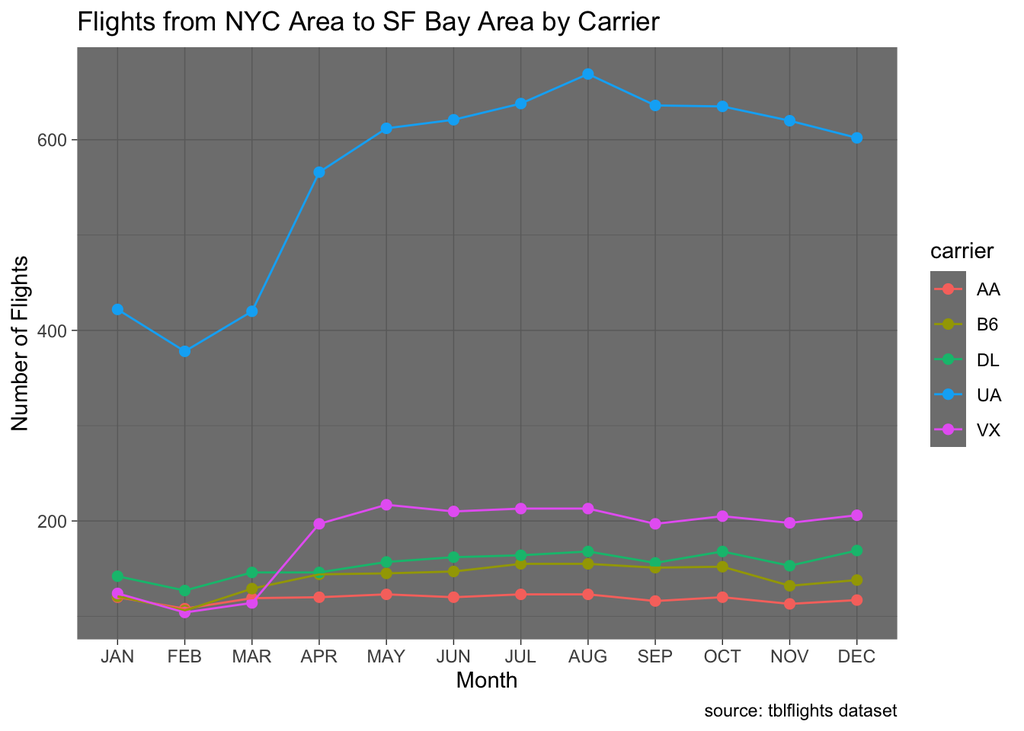

```r
tblflights %>%
  filter((origin == "JFK" | origin == "LGA" | origin == "EWR") & (dest == "SFO" | dest == "SJC" | dest == "OAK")) %>%
  group_by(carrier, month) %>%
  summarize(sum = length(carrier)) %>%
  ggplot(aes(x = month, y = sum)) +
  geom_point(aes(col=carrier), size=2) +
  geom_line(aes(col=carrier)) +
  labs(title = "Flights from NYC Area to SF Bay Area by Carrier",
          x = "Month",
          y = "Number of Flights",
          caption = "source: tblflights dataset") +
  scale_x_discrete(limits=c("JAN","FEB","MAR", "APR", "MAY", "JUN", "JUL", "AUG", "SEP", "OCT", "NOV", "DEC")) +
  theme_dark()
```

# Acknowledgements